# Report COVID study NL 212

Thijs de Boer

2021

Last update: 2021-03-11 15:54:31

```r
load("C:/Users/Thijs/surfdrive/COVID vaccine/git/NL/.RData")

set_theme(
  base=theme_blank(),
  geom.outline.size = 0.01,
  geom.outline.color = "white",
  geom.label.size = 3,
  geom.label.color = "grey50")
```

# 1 Population

Total number of participants:

```r
df.total %>% nrow()
```

```
## [1] 1346
```

Number of participants that failed the attention test:

```r
df.total %>% nrow() - df.total %>% filter(IMC=="1") %>% nrow()
```

```
## [1] 331
```

Participants between 0-17:

```r
df.total %>% filter(IMC=="1" & age < 18) %>% nrow()
```

```
## [1] 0
```

Percentage of participants who are at least 18 years old and did not fail the IMC:

```r
percent((df.def %>% nrow() / df.total %>% nrow()))
```

```
## [1] "75%"
```

Number of participants in this analysis:

```r
df.def %>% nrow()
```

```
## [1] 1015
```

Number of participants in the final dataset that failed the manipulation check:

```r
df.def %>% nrow() - df.def %>% filter(manipulation.check=="1") %>% nrow()
```

```
## [1] 383
```

Which is:

```r
percent(df.def %>% filter(manipulation.check!="1") %>% nrow() / df.def %>% nrow(), accuracy = 0.01)
```

```
## [1] "37.73%"
```

# 2 Experiment: Perceived independence of EMA

## 2.1 Randomisation check

This table shows how many respondents are assigned to each experimental group.

```r
df.def %>%
  group_by(experimental.group) %>%
  tally()
```

```
## # A tibble: 2 x 2
##   experimental.group     n
## * <chr>              <int>
## 1 control              518
## 2 treatment            497
```

## 2.2 Description

```r
df.def %>%
sjmisc::descr(perceived.independence.reversed, show = c("n", "NA.prc", "mean", "sd", "md", "iqr", "trimmed", "range", "skew")) %>%
  kbl(digits= 2) %>%
 kable_paper()
```

| var | n | NA.prc | mean | sd | md | trimmed | range | iqr | skew |
| --- | --- | --- | --- | --- | --- | --- | --- | --- | --- |
| perceived.independence.reversed | 1015 | 0 | 3.47 | 1.47 | 3 | 3.41 | 6 (1-7) | 2 | 0.35 |

## 2.3 Histogram

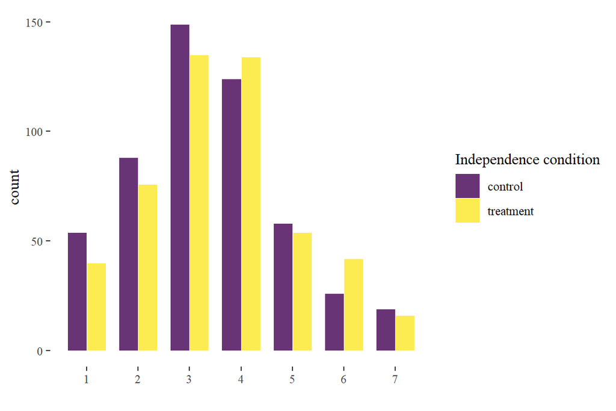

```r
df.def %>%
  ggplot(aes(x = perceived.independence.reversed, fill = experimental.group)) +
  geom_bar(width = 0.75,alpha = 0.8, position = position_dodge()) +
  scale_x_continuous(name="", breaks = 1:7) + scale_fill_manual(name = "Independence condition") +  scale_fill_viridis_d(name = "Independence condition") +
  theme_tufte()
```

## 2.4 T-test

### 2.4.1 With complete dataset

```r
tadaa_t.test(data = df.def, response = perceived.independence.reversed, group = experimental.group, print = "markdown")
```

Table 1: **Welch Two Sample t-test** with alternative hypothesis: $\mu_1 \neq \mu_2$

| Diff | $\mu_1$ control | $\mu_2$ treatment | t | SE | df | $CI_{95\%}$ | p | Cohen's d |
| --- | --- | --- | --- | --- | --- | --- | --- | --- |
| -0.17 | 3.38 | 3.56 | -1.88 | 0.09 | 1011.63 | (-0.35 - 0.01) | .061 | -0.12 |

* Not significant

### 2.4.2 With those who failed the manipulation check filtered out

```r
tadaa_t.test(data = df.check, response = perceived.independence.reversed, group = experimental.group, print = "markdown")
```

Table 2: **Welch Two Sample t-test** with alternative hypothesis: $\mu_1 \neq \mu_2$

| Diff | $\mu_1$ control | $\mu_2$ treatment | t | SE | df | $CI_{95\%}$ | p | Cohen's d |
| --- | --- | --- | --- | --- | --- | --- | --- | --- |
| -0.35 | 3.36 | 3.72 | -2.95 | 0.12 | 630 | (-0.59 - -0.12) | < .01 | -0.23 |

* Significant!

# 3 Time

## 3.1 Survey duration

### 3.1.1 Histogram

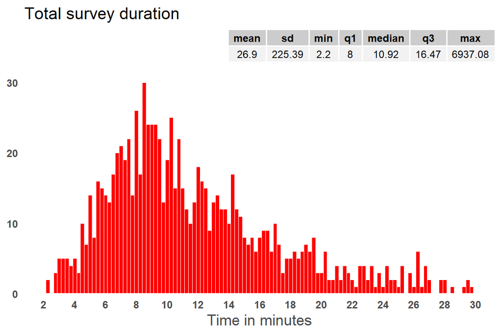

```r
df.def %>% filter(duration < 30) %>%
plot_frq((duration),
        geom.colors = alpha("red",0.8),
        type = "hist",
        geom.size = 0.25) +
  theme(axis.text = element_text(face = "bold",  size= 9)) + labs(title = "Total survey duration") +  scale_x_continuous(name="Time in minutes", breaks = seq(0,30, 2)) + scale_y_continuous(expand = expansion(c(0, 0.25))) + annotate(geom = "table", x = Inf, y = Inf, label = list(table.duration))
```

## 3.2 Do participants read the information about the case?

### 3.2.1 Page submission - introduction of case

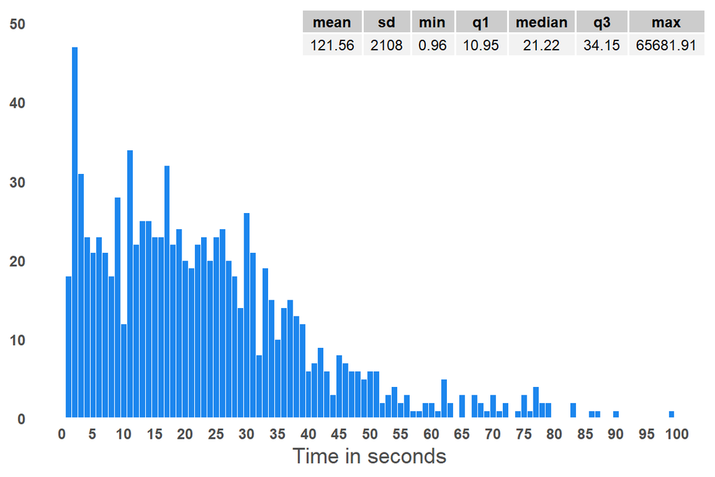

```r
df.def %>% filter(intro.submit < 100) %>%
plot_frq((intro.submit),
        geom.colors = alpha("dodgerblue2",0.8),
        type = "hist",
        geom.size = 1) +
  theme(axis.text = element_text(face = "bold",  size= 9)) +
  scale_x_continuous(name="Time in seconds",breaks = seq(0,100,5)) + scale_y_continuous(expand = expansion(c(0, 0.1))) + annotate(geom = "table", x = Inf, y = Inf, label = list(table.intro.submit))
```

### 3.2.2 Page submission - manipulation

*Histogram*

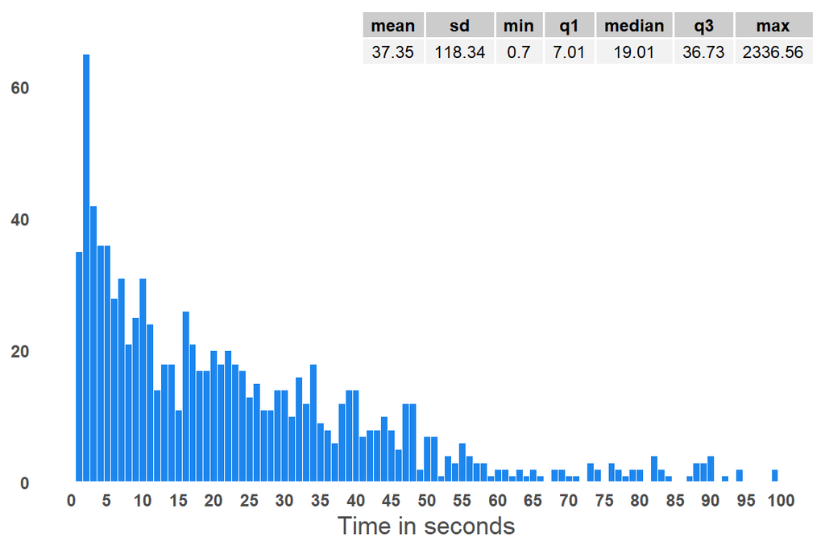

```r
df.def %>% filter(manipulation.submit < 100) %>%
plot_frq((manipulation.submit),
        geom.colors = alpha("dodgerblue2",0.8),
        type = "hist",
        geom.size = 1) +
  theme(axis.text = element_text(face = "bold",  size= 9)) +
  scale_x_continuous(name="Time in seconds",breaks = seq(0,100,5)) + scale_y_continuous(expand = expansion(c(0, 0.1))) + annotate(geom = "table", x = Inf, y = Inf, label = list(table.manipulation.submit))
```

*Relationship between perceived independence and time spent on the page with the manipulation*

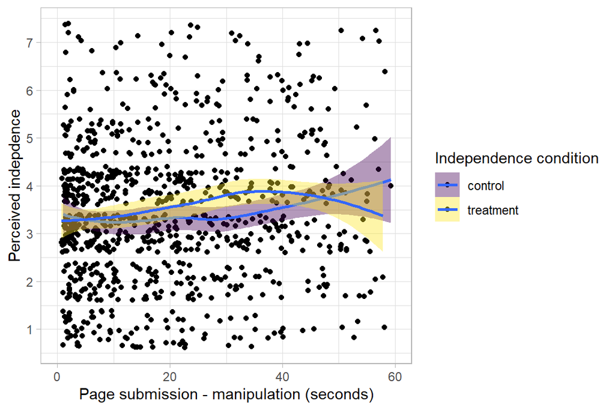

```r
df.def %>% filter(manipulation.submit < 60) %>% ggplot(aes(manipulation.submit, perceived.independence.reversed, fill = experimental.group)) + geom_jitter() + geom_smooth() + scale_x_continuous("Page submission - manipulation (seconds)", limits = c(0,60)) + scale_y_continuous("Perceived indepdence", breaks = 1:7) + scale_fill_viridis_d(name = "Independence condition") + theme_light()
```

*Broken down in quartiles (+ group size and CI)*

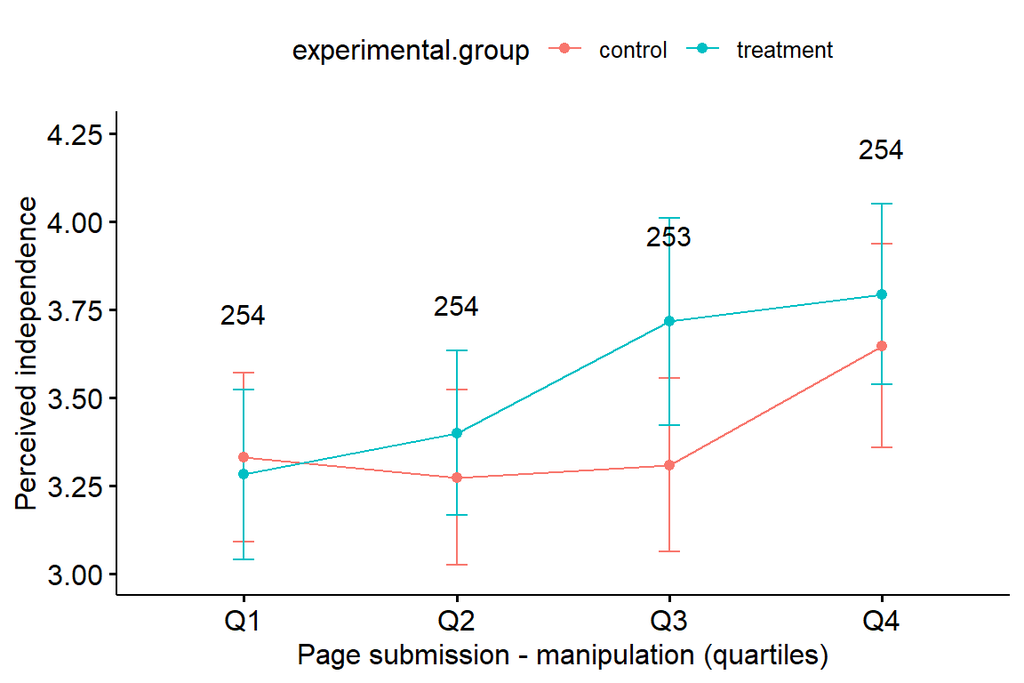

```r
give.n <- function(x){
  return(c(y = mean(x)*1.13, label = length(x)))
}

ggline(df.def, x = "manipulation.submit.quartile", y = "perceived.independence.reversed", color = "experimental.group", ylab = "Perceived independence", xlab = "Page submission - manipulation (quartiles)",  add = "mean_ci", ylim = c(3, 4.25), yticks.by = 0.25) +
  stat_summary(fun.data = give.n, geom = "text", fun = median, size = 4, col = "black")
```

*Split dataset with 30 seconds as cut-off point (+ group size and CI)*

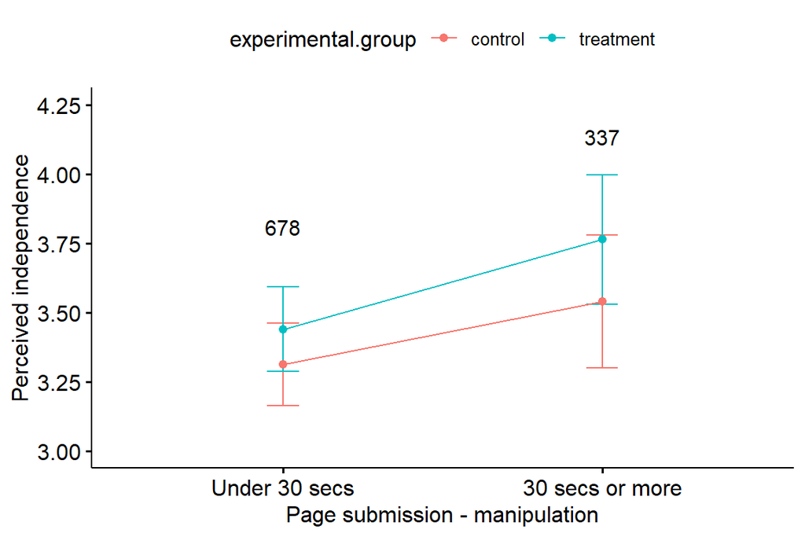

```r
ggline(df.def, x = "manipulation.submit.30", y = "perceived.independence.reversed", color = "experimental.group", ylab = "Perceived independence", xlab = "Page submission - manipulation",  add = c("mean_ci"), ylim = c(3, 4.25), yticks.by = 0.25) +
  stat_summary(fun.data = give.n, geom = "text", fun = median, size = 4, col = "black")
```

### 3.2.3 Page submission - EMA’s decision

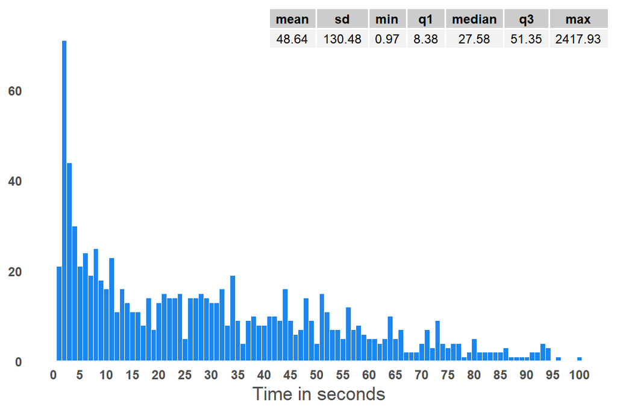

```r
df.def %>% filter(decision.submit < 100) %>%
plot_frq((decision.submit),
        geom.colors = alpha("dodgerblue2",0.8),
        type = "hist",
        geom.size = 1) +
  theme(axis.text = element_text(face = "bold",  size= 9)) +
  scale_x_continuous(name= "Time in seconds", breaks = seq(0,100,5)) + scale_y_continuous(expand = expansion(c(0, 0.1))) + annotate(geom = "table", x = Inf, y = Inf, label = list(table.decision.submit))
```

## 3.3 Time and …

### 3.3.1 …Failing the manipulation check

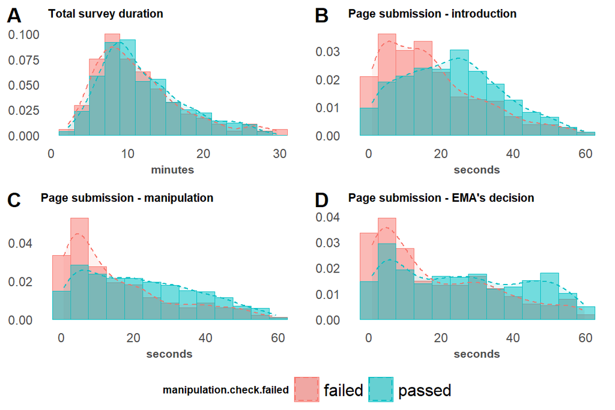

```r
p1 <- df.def %>% filter(duration < 30) %>% ggplot(aes(x= duration, color = manipulation.check.failed, fill = manipulation.check.failed)) + geom_histogram(aes(y=..density..), alpha=0.5, position="identity", binwidth = 2) +
 geom_density(alpha= .1, linetype= "dashed") + labs(title = "Total survey duration", x = "minutes") + theme(axis.title.y = element_blank(), title = element_text(size = 7, face = "bold"),  axis.text = element_text(size = 9))

p2  <- df.def %>% filter(intro.submit < 60) %>% ggplot(aes(x= intro.submit, color = manipulation.check.failed, fill = manipulation.check.failed)) + geom_histogram(aes(y=..density..), alpha=0.5, position="identity", binwidth = 5) +
 geom_density(alpha= .1, linetype= "dashed") + labs(title = "Page submission - introduction", x = "seconds") + theme(axis.title.y = element_blank(), title = element_text(size = 7, face = "bold"),  axis.text = element_text(size = 9))

p3 <- df.def %>% filter(manipulation.submit < 60) %>% ggplot(aes(x=manipulation.submit, color = manipulation.check.failed, fill = manipulation.check.failed)) + geom_histogram(aes(y=..density..), alpha=0.5, position="identity", binwidth = 5) + geom_density(alpha= .1, linetype= "dashed") + labs(title = "Page submission - manipulation", x = "seconds") + theme(axis.title.y = element_blank(), title = element_text(size = 7, face = "bold"),  axis.text = element_text(size = 9))

p4 <- df.def %>% filter(decision.submit < 60) %>% ggplot(aes(x=decision.submit, color =manipulation.check.failed, fill = manipulation.check.failed)) +
 geom_histogram(aes(y=..density..), alpha=0.5, position="identity", binwidth = 5) +
 geom_density(alpha= .1, linetype= "dashed") + labs(title = "Page submission - EMA's decision", x = "seconds", color = "Manipulation Check") + theme(axis.title.y = element_blank(), title = element_text(size = 7, face = "bold"),  axis.text = element_text(size = 9))

ggarrange(p1, p2, p3, p4, nrow = 2, ncol = 2, labels="AUTO", legend = "bottom", common.legend = TRUE)
```

### 3.3.2 …experimental groups

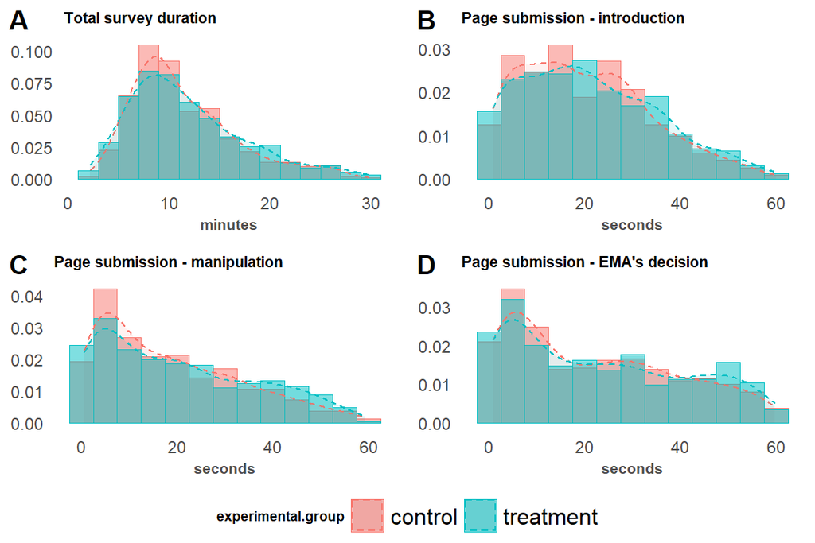

```r
p5 <- df.def %>% filter(duration < 30) %>% ggplot(aes(x= duration, color = experimental.group, fill = experimental.group)) + geom_histogram(aes(y=..density..), alpha=0.5, position="identity", binwidth = 2) +
 geom_density(alpha= .1, linetype= "dashed") + labs(title = "Total survey duration", x = "minutes") + theme(axis.title.y = element_blank(), title = element_text(size = 7, face = "bold"),  axis.text = element_text(size = 9))

p6  <- df.def %>% filter(intro.submit < 60) %>% ggplot(aes(x= intro.submit, color = experimental.group, fill = experimental.group)) + geom_histogram(aes(y=..density..), alpha=0.5, position="identity", binwidth = 5) +
 geom_density(alpha= .1, linetype= "dashed") + labs(title = "Page submission - introduction", x = "seconds") + theme(axis.title.y = element_blank(), title = element_text(size = 7, face = "bold"),  axis.text = element_text(size = 9))

p7 <- df.def %>% filter(manipulation.submit < 60) %>% ggplot(aes(x=manipulation.submit, color = experimental.group, fill = experimental.group)) + geom_histogram(aes(y=..density..), alpha=0.5, position="identity", binwidth = 5) + geom_density(alpha= .1, linetype= "dashed") + labs(title = "Page submission - manipulation", x = "seconds") + theme(axis.title.y = element_blank(), title = element_text(size = 7, face = "bold"),  axis.text = element_text(size = 9))

p8 <- df.def %>% filter(decision.submit < 60) %>% ggplot(aes(x=decision.submit, color = experimental.group, fill = experimental.group)) +
 geom_histogram(aes(y=..density..), alpha=0.5, position="identity", binwidth = 5) +
 geom_density(alpha= .1, linetype= "dashed") + labs(title = "Page submission - EMA's decision", x = "seconds", color = "Manipulation Check") + theme(axis.title.y = element_blank(), title = element_text(size = 7, face = "bold"),  axis.text = element_text(size = 9))

ggarrange(p5, p6, p7, p8, nrow = 2, ncol = 2, labels="AUTO", legend = "bottom", common.legend = TRUE)
```

T-tests (outliers removed - i.e., cases outside 1.5 times the interquartile range):

*Survey duration*

```r
tadaa_t.test(data = out.duration, response = duration, group = experimental.group, print = "markdown")
```

Table 3: **Welch Two Sample t-test** with alternative hypothesis: $\mu_1 \neq \mu_2$

| Diff | $\mu_1$ control | $\mu_2$ treatment | t | SE | df | $CI_{95\%}$ | p | Cohen's d |
| --- | --- | --- | --- | --- | --- | --- | --- | --- |
| -0.3 | 11.48 | 11.77 | -0.84 | 0.35 | 922.72 | (-0.99 - 0.4) | .402 | -0.06 |

*Page submission - Introduction*

```r
tadaa_t.test(data = out.intro.submit, response = intro.submit, group = experimental.group, print = "markdown")
```

Table 4: **Welch Two Sample t-test** with alternative hypothesis: $\mu_1 \neq \mu_2$

| Diff | $\mu_1$ control | $\mu_2$ treatment | t | SE | df | $CI_{95\%}$ | p | Cohen's d |
| --- | --- | --- | --- | --- | --- | --- | --- | --- |
| -0.5 | 21.36 | 21.86 | -0.52 | 0.96 | 936.33 | (-2.39 - 1.39) | .605 | -0.03 |

*Page submission - manipulation*

```r
tadaa_t.test(data = out.manipulation.submit, response = manipulation.submit, group = experimental.group, print = "markdown")
```

Table 5: **Welch Two Sample t-test** with alternative hypothesis: $\mu_1 \neq \mu_2$

| Diff | $\mu_1$ control | $\mu_2$ treatment | t | SE | df | $CI_{95\%}$ | p | Cohen's d |
| --- | --- | --- | --- | --- | --- | --- | --- | --- |
| -1.79 | 20.39 | 22.18 | -1.57 | 1.14 | 940.72 | (-4.03 - 0.45) | .117 | -0.1 |

*Page submission - decision*

```r
tadaa_t.test(data = out.decision.submit, response = decision.submit, group = experimental.group, print = "markdown")
```

Table 6: **Welch Two Sample t-test** with alternative hypothesis: $\mu_1 \neq \mu_2$

| Diff | $\mu_1$ control | $\mu_2$ treatment | t | SE | df | $CI_{95\%}$ | p | Cohen's d |
| --- | --- | --- | --- | --- | --- | --- | --- | --- |
| 0.98 | 30.87 | 29.89 | 0.6 | 1.64 | 954.92 | (-2.24 - 4.2) | .55 | 0.04 |

### 3.3.3 …interface (pc/mobile)

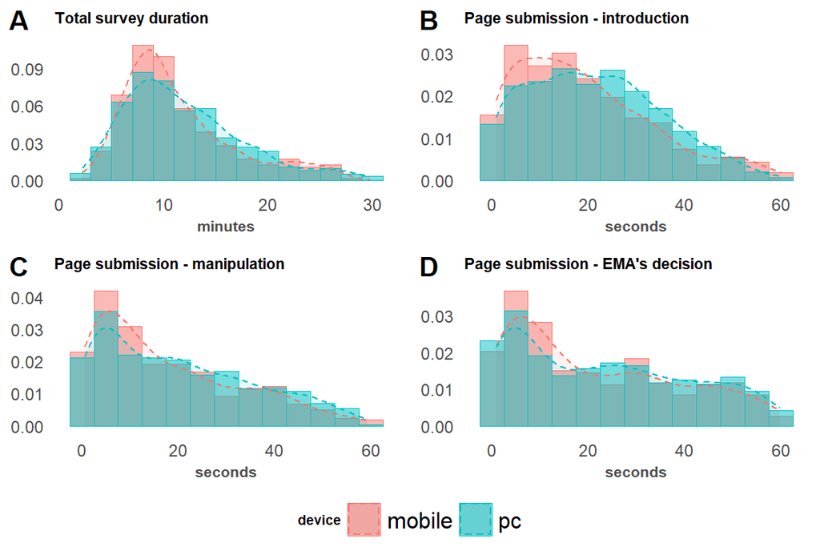

```r
p9 <- df.def %>% filter(duration < 30) %>% ggplot(aes(x= duration, color = device, fill = device)) + geom_histogram(aes(y=..density..), alpha=0.5, position="identity", binwidth = 2) +
 geom_density(alpha= .1, linetype= "dashed") + labs(title = "Total survey duration", x = "minutes") + theme(axis.title.y = element_blank(), title = element_text(size = 7, face = "bold"),  axis.text = element_text(size = 9))

p10 <- df.def %>% filter(intro.submit < 60) %>% ggplot(aes(x= intro.submit, color = device, fill = device)) + geom_histogram(aes(y=..density..), alpha=0.5, position="identity", binwidth = 5) +
 geom_density(alpha= .1, linetype= "dashed") + labs(title = "Page submission - introduction", x = "seconds") + theme(axis.title.y = element_blank(), title = element_text(size = 7, face = "bold"),  axis.text = element_text(size = 9))

p11 <- df.def %>% filter(manipulation.submit < 60) %>% ggplot(aes(x=manipulation.submit, color = device, fill = device)) + geom_histogram(aes(y=..density..), alpha=0.5, position="identity", binwidth = 5) + geom_density(alpha= .1, linetype= "dashed") + labs(title = "Page submission - manipulation", x = "seconds") + theme(axis.title.y = element_blank(), title = element_text(size = 7, face = "bold"),  axis.text = element_text(size = 9))

p12 <- df.def %>% filter(decision.submit < 60) %>% ggplot(aes(x=decision.submit, color = device, fill = device)) +
 geom_histogram(aes(y=..density..), alpha=0.5, position="identity", binwidth = 5) +
 geom_density(alpha= .1, linetype= "dashed") + labs(title = "Page submission - EMA's decision", x = "seconds", color = "Manipulation Check") + theme(axis.title.y = element_blank(), title = element_text(size = 7, face = "bold"),  axis.text = element_text(size = 9))

ggarrange(p9, p10, p11, p12, nrow = 2, ncol = 2, labels="AUTO", legend = "bottom", common.legend = TRUE)
```

# 4 Vaccination intention

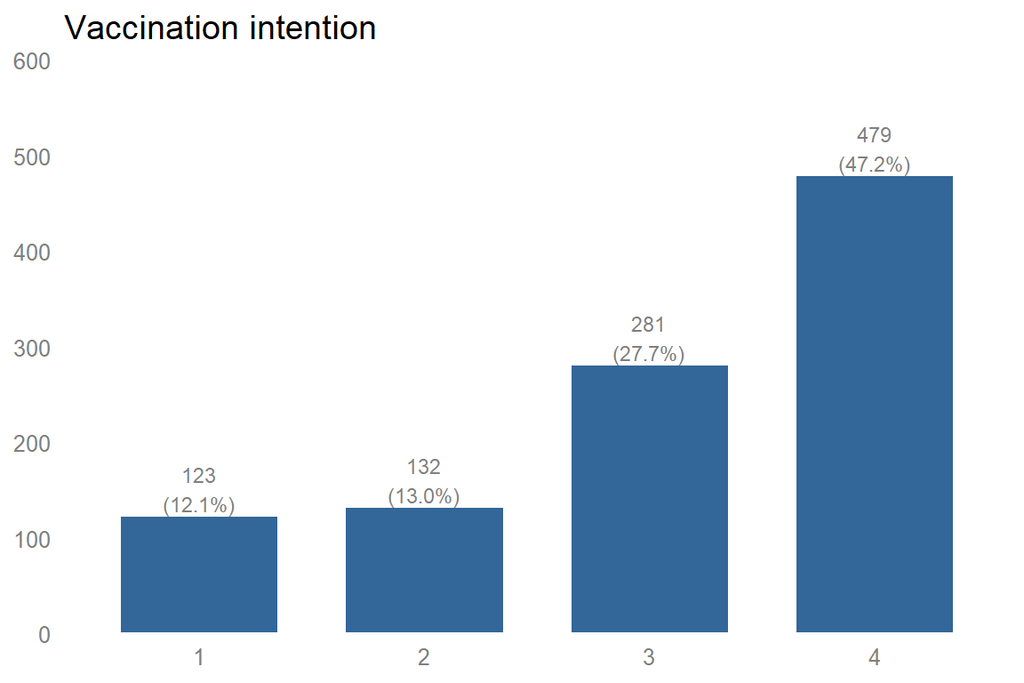

```r
df.def %>%
plot_frq(intent.vaccine,
        title = "Vaccination intention") +
  theme_blank() +
  theme(axis.title  = element_blank())
```

## 4.1 Open question

```r
df.def %>%
  filter(nchar(Q16.3)>1) %>%
  select(Q16.3) %>%
  kable() %>%
  kable_styling(bootstrap_options = "striped", full_width = F) %>%    scroll_box(height = "400px")
```

[output not shown]

# 5 Interface (mobile/pc)

## 5.1 Distribution

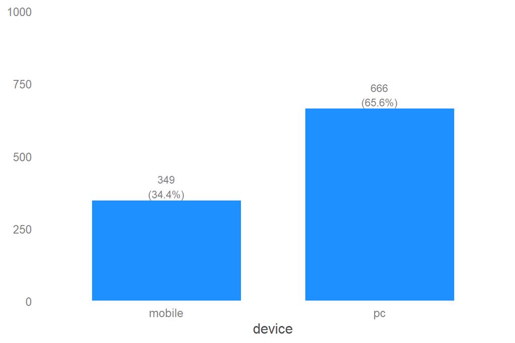

```r
df.def %>%
  plot_frq(device,
        ylim = c(0,nrow(df.def)),
        geom.colors = alpha("dodgerblue1",0.8))+
  theme_blank()
```

## 5.2 Distribution of perceived independence for mobile/pc

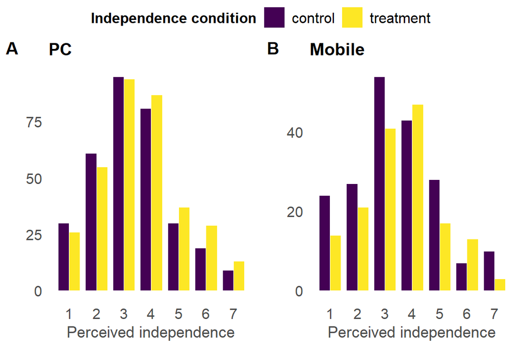

```r
p13 <- df.def %>%
  drop_na(perceived.independence.reversed) %>% filter(device == "pc") %>%
  ggplot(aes(x = perceived.independence.reversed, fill = experimental.group)) + labs(title = "PC") +
  geom_bar(width = 0.8, alpha = 1, position = position_dodge()) +
  scale_x_continuous(name="Perceived independence", breaks = 1:7) + scale_y_continuous(name="") + scale_fill_manual(name = "Independence condition", values = c("dodgerblue2","dodgerblue4")) +
theme(plot.title = element_text(face = "bold")) +  scale_fill_viridis_d(name = "Independence condition")

p14 <- df.def %>% filter(device == "mobile") %>%
  ggplot(aes(x = perceived.independence.reversed, fill = experimental.group)) + labs(title = "Mobile") +
  geom_bar(width = 0.8, alpha = 1, position = position_dodge())+
  scale_x_continuous(name="Perceived independence", breaks = 1:7) + scale_y_continuous(name="") + scale_fill_manual(name = "Independence condition", values = c("dodgerblue2","dodgerblue4")) +
theme(plot.title = element_text(face = "bold")) +  scale_fill_viridis_d(name = "Independence condition")

ggarrange(p13, p14,
          ncol = 2,nrow = 1, common.legend = TRUE, labels = "AUTO")
```

### 5.2.1 T-test

```r
tadaa_t.test(data = df.def, response = perceived.independence.reversed, group = device, print = "markdown")
```

Table 7: **Welch Two Sample t-test** with alternative hypothesis: $\mu_1 \neq \mu_2$

| Diff | $\mu_1$ mobile | $\mu_2$ pc | t | SE | df | $CI_{95\%}$ | p | Cohen's d |
| --- | --- | --- | --- | --- | --- | --- | --- | --- |
| 0.02 | 3.48 | 3.46 | 0.22 | 0.1 | 692.94 | (-0.17 - 0.21) | .823 | 0.01 |

# 6 Descriptive statistics

## 6.1 Demography

**Age**

Sample:

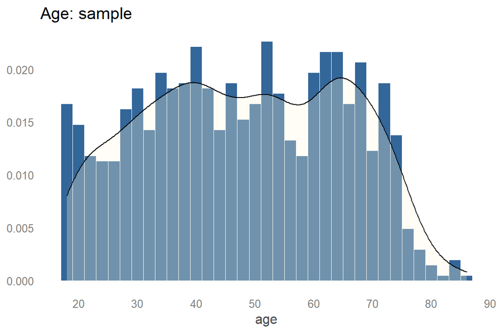

```r
df.def %>%
plot_frq(age,
        type = "density",
        title = "Age: sample") +
  scale_x_continuous(breaks = seq(0,100,10))+
  theme_blank()
```

Comparing age in sample and true population:

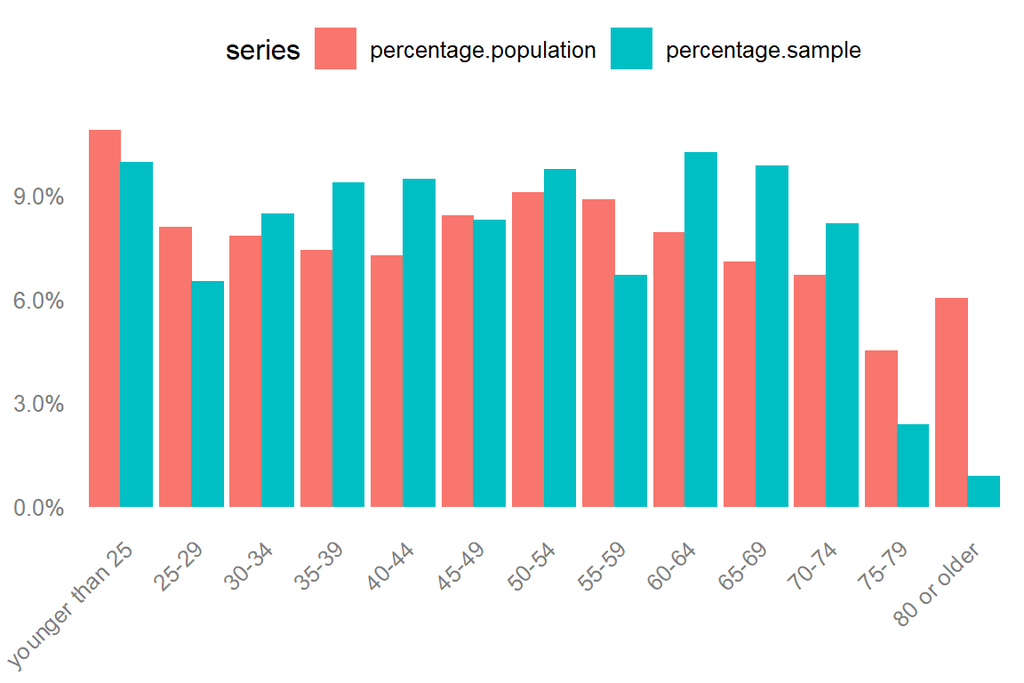

```r
age.population.5 <- read.csv("C:/Users/Thijs/surfdrive/COVID vaccine/git/NL/AGE_POPULATION_SEGMENTS_NL-22012021.csv")
age.total <- merge(age.population.5, age.sample, by.x = "ï..age", by.y = ".")

age.total <- age.total %>%
  rename(age.category = ï..age,
  count.population = count,
  count.sample = n,
  percentage.population = percentage.x,
  percentage.sample = percentage.y)

age.total$age.category <- factor(age.total$age.category, levels = c(
"younger than 25",
"25-29",           "30-34",           "35-39",
"40-44",           "45-49",           "50-54",
"55-59",           "60-64",           "65-69",
"70-74",           "75-79",           "80 or older"))

age.total %>% select(age.category, percentage.population, percentage.sample) %>% reshape2::melt(id.vars = 'age.category', variable.name = 'series')  %>% ggplot(aes(age.category, value, colour = series, fill = series)) + geom_bar (stat="identity", width=0.9, position = position_dodge(width=0.9)) +
  theme_blank() + theme(legend.position="top", axis.text.x = element_text(angle = 45, hjust = 1), axis.title  = element_blank()) + scale_y_continuous(labels=scales::percent)
```

**Gender**

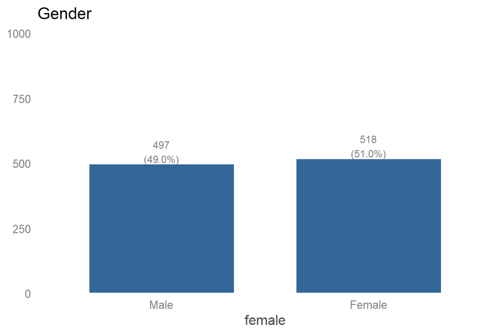

```r
df.def %>%
plot_frq(female,
                ylim = c(0,nrow(df.def)),
        axis.labels = c("Male","Female"),
        title = "Gender")+
  theme_blank()
```

**Education**

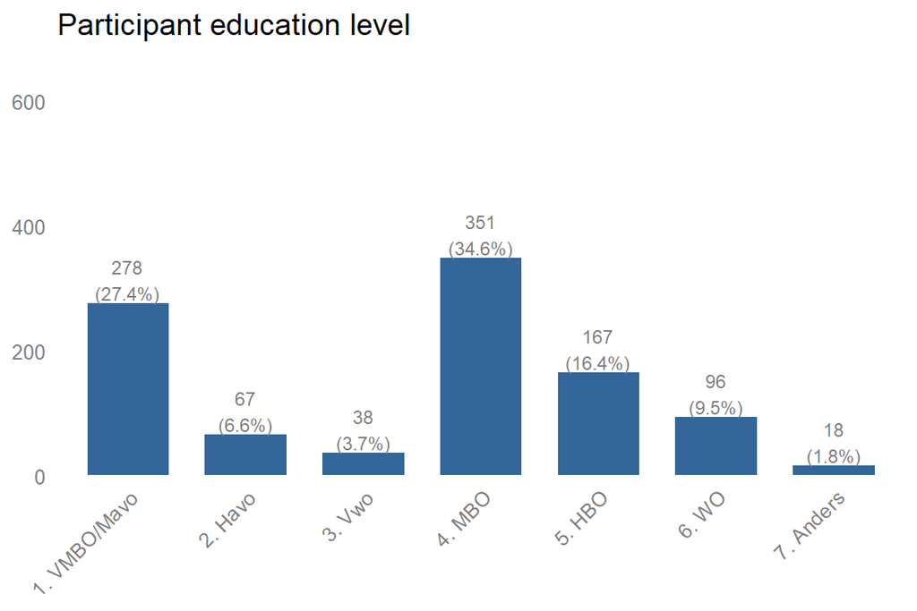

```r
df.def %>%
  filter(education.recoded!="0") %>%
  arrange(education.recoded)  %>%
  plot_frq(education.recoded,
        ylim = c(0,nrow(df.def)/1.5),
        title = "Participant education level") +
  theme_blank() + theme(axis.text.x = element_text(angle = 45, hjust = 1), axis.title  = element_blank())
```

Compare with true population:

[figure not shown]

Source: CBS.

**Income**

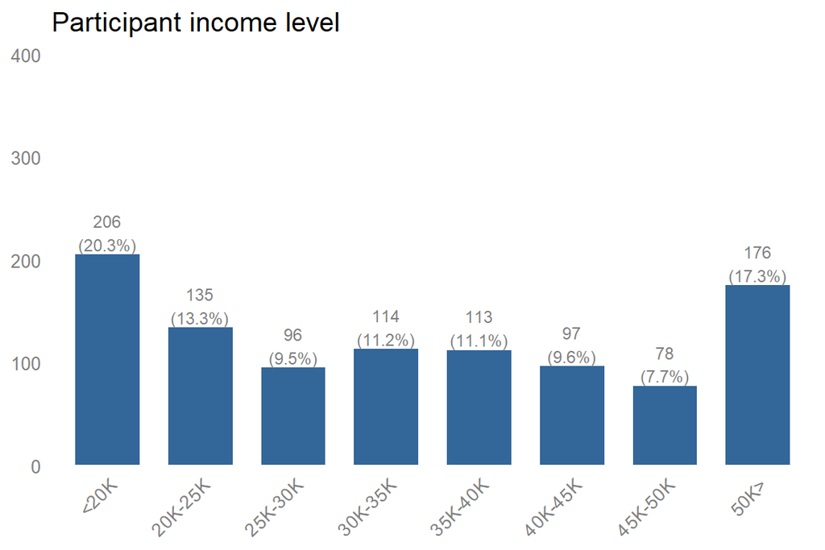

```r
df.def %>%
  filter(income!=0) %>%
  plot_frq(income,
        ylim = c(0,nrow(df.def)/2.5),
        title = "Participant income level") +
  theme_blank() + theme(axis.text.x = element_text(angle = 45, hjust = 1), axis.title  = element_blank())
```

**Province**

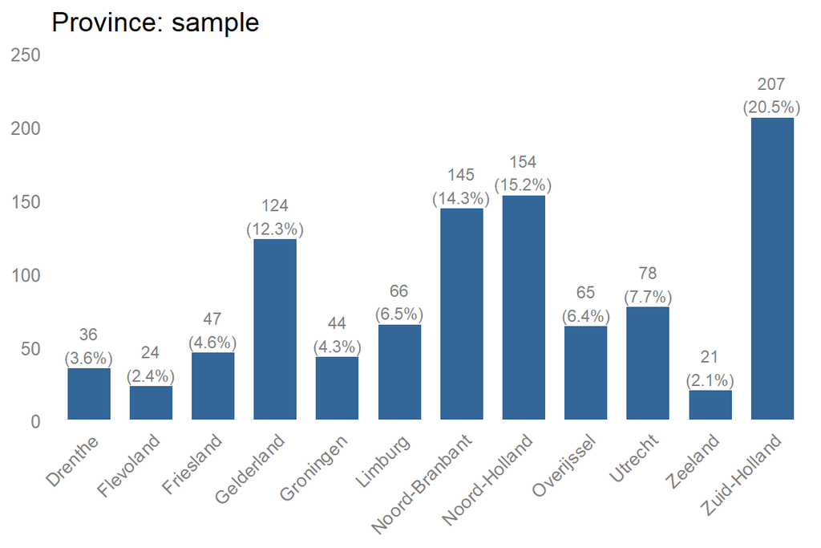

```r
df.def %>%
  plot_frq(province,
        ylim = c(0,nrow(df.def)/4),
        title = "Province: sample") +
  theme_blank()+
  theme(axis.text.x = element_text(angle = 45, hjust = 1), axis.title  = element_blank())
```

Compare with true population:

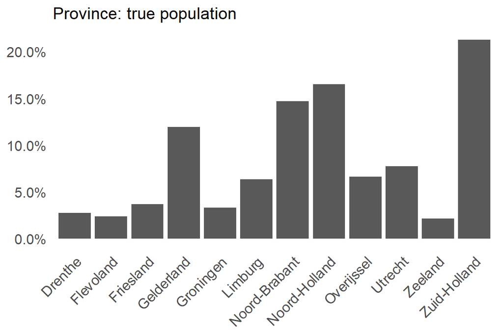

```r
provinces <- read.csv("C:/Users/Thijs/surfdrive/COVID vaccine/git/NL/PROVINCES_NL-22012021.csv")

provinces %>%
  rename(province = ï..province)  %>%
  arrange(province) %>%
ggplot(aes(x = province, y = percentage)) + geom_bar(stat="identity") +
  theme(axis.text.x = element_text(angle = 45, hjust = 1), axis.title  = element_blank()) + labs(title = "Province: true population") + scale_y_continuous(labels=scales::percent)
```

Source: CBS.

**Works in healthcare sector**

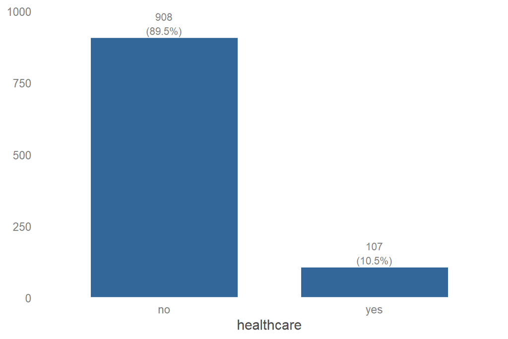

```r
df.def %>%
  plot_frq(healthcare,
        ylim = c(0,nrow(df.def)),
        title = "") +
  theme_blank()
```

## 6.2 Key variables

### 6.2.1 Statistics

```r
df.def %>% select(benefits.vaccines, intent.vaccine:importance.NRA, knowledge) %>%
sjmisc::descr(show = c("n", "NA.prc", "mean", "sd", "md", "iqr", "trimmed", "range", "skew")) %>%
  kbl(digits= 2) %>%
 kable_paper()
```

|  | var | n | NA.prc | mean | sd | md | trimmed | range | iqr | skew |
| --- | --- | --- | --- | --- | --- | --- | --- | --- | --- | --- |
| 1 | benefits.vaccines | 1015 | 0 | 5.07 | 1.60 | 5.00 | 5.26 | 6 (1-7) | 2.00 | -0.85 |
| 23 | intent.vaccine | 1015 | 0 | 3.10 | 1.04 | 3.00 | 3.25 | 3 (1-4) | 2.00 | -0.85 |
| 24 | intent.vaccine.recoded | 1015 | 0 | 0.75 | 0.43 | 1.00 | 0.81 | 1 (0-1) | 1.00 | -1.15 |
| 9 | credibility.item1 | 1015 | 0 | 4.81 | 1.51 | 5.00 | 4.92 | 6 (1-7) | 2.00 | -0.64 |
| 10 | credibility.item2.reversed | 1015 | 0 | 3.86 | 1.69 | 4.00 | 3.87 | 6 (1-7) | 2.00 | 0.04 |
| 11 | credibility.item3.reversed | 1015 | 0 | 3.92 | 1.71 | 4.00 | 3.92 | 6 (1-7) | 2.00 | 0.02 |
| 12 | credibility.item4 | 1015 | 0 | 5.13 | 1.41 | 5.00 | 5.27 | 6 (1-7) | 2.00 | -0.89 |
| 13 | credibility.item5 | 1015 | 0 | 5.02 | 1.46 | 5.00 | 5.15 | 6 (1-7) | 2.00 | -0.81 |
| 14 | credibility.item6 | 1015 | 0 | 5.12 | 1.35 | 5.00 | 5.20 | 6 (1-7) | 2.00 | -0.55 |
| 16 | credibility.stability | 1015 | 0 | 5.12 | 1.35 | 5.00 | 5.20 | 6 (1-7) | 2.00 | -0.55 |
| 8 | credibility.index | 1015 | 0 | 4.64 | 1.12 | 4.67 | 4.66 | 6 (1-7) | 1.33 | -0.21 |
| 7 | credibility.expert | 1015 | 0 | 5.07 | 1.33 | 5.00 | 5.17 | 6 (1-7) | 2.00 | -0.83 |
| 15 | credibility.noninterference | 1015 | 0 | 4.20 | 1.34 | 4.00 | 4.21 | 6 (1-7) | 1.67 | -0.06 |
| 30 | trust.EC | 1015 | 0 | 4.05 | 1.45 | 4.00 | 4.13 | 6 (1-7) | 2.00 | -0.46 |
| 31 | trust.EP | 1015 | 0 | 4.00 | 1.48 | 4.00 | 4.08 | 6 (1-7) | 2.00 | -0.40 |
| 29 | trust.council | 1015 | 0 | 3.99 | 1.42 | 4.00 | 4.06 | 6 (1-7) | 2.00 | -0.41 |
| 34 | trust.scientist | 1015 | 0 | 5.03 | 1.31 | 5.00 | 5.11 | 6 (1-7) | 2.00 | -0.73 |
| 33 | trust.politicians | 1015 | 0 | 3.93 | 1.52 | 4.00 | 4.02 | 6 (1-7) | 2.00 | -0.43 |
| 28 | political.ideology | 1015 | 0 | 4.19 | 1.33 | 4.00 | 4.20 | 6 (1-7) | 2.00 | -0.02 |
| 17 | EU.integration | 1015 | 0 | 3.70 | 1.56 | 4.00 | 3.71 | 6 (1-7) | 2.00 | -0.18 |
| 25 | interpersonal.trust | 1015 | 0 | 4.00 | 1.57 | 4.00 | 4.07 | 6 (1-7) | 2.00 | -0.27 |
| 19 | familiarity.EMA | 1015 | 0 | 4.07 | 1.50 | 4.00 | 4.11 | 6 (1-7) | 2.00 | -0.21 |
| 18 | familiarity.advice | 1015 | 0 | 4.69 | 1.55 | 5.00 | 4.80 | 6 (1-7) | 2.00 | -0.53 |
| 4 | credibility.ECB | 1015 | 0 | 4.24 | 1.45 | 4.00 | 4.35 | 6 (1-7) | 1.00 | -0.53 |
| 6 | credibility.EMA | 1015 | 0 | 4.61 | 1.47 | 5.00 | 4.72 | 6 (1-7) | 2.00 | -0.61 |
| 5 | credibility.EFSA | 1015 | 0 | 4.65 | 1.40 | 5.00 | 4.75 | 6 (1-7) | 2.00 | -0.63 |
| 32 | trust.health.authorities | 1015 | 0 | 4.74 | 1.64 | 5.00 | 4.88 | 6 (1-7) | 2.00 | -0.71 |
| 27 | perceived.independence.reversed | 1015 | 0 | 3.47 | 1.47 | 3.00 | 3.41 | 6 (1-7) | 2.00 | 0.35 |
| 3 | consequences.health | 1015 | 0 | 4.98 | 1.65 | 5.00 | 5.17 | 6 (1-7) | 2.00 | -0.75 |
| 2 | consequences.economic | 1015 | 0 | 3.85 | 1.84 | 4.00 | 3.81 | 6 (1-7) | 3.00 | 0.03 |
| 20 | importance.EMA | 1015 | 0 | 2.94 | 0.99 | 3.00 | 3.05 | 3 (1-4) | 2.00 | -0.64 |
| 21 | importance.FDA | 1015 | 0 | 2.52 | 0.92 | 3.00 | 2.53 | 3 (1-4) | 1.00 | -0.18 |
| 22 | importance.NRA | 1015 | 0 | 2.96 | 0.97 | 3.00 | 3.07 | 3 (1-4) | 2.00 | -0.68 |
| 26 | knowledge | 1015 | 0 | 0.65 | 0.48 | 1.00 | 0.68 | 1 (0-1) | 1.00 | -0.62 |

### 6.2.2 Plots

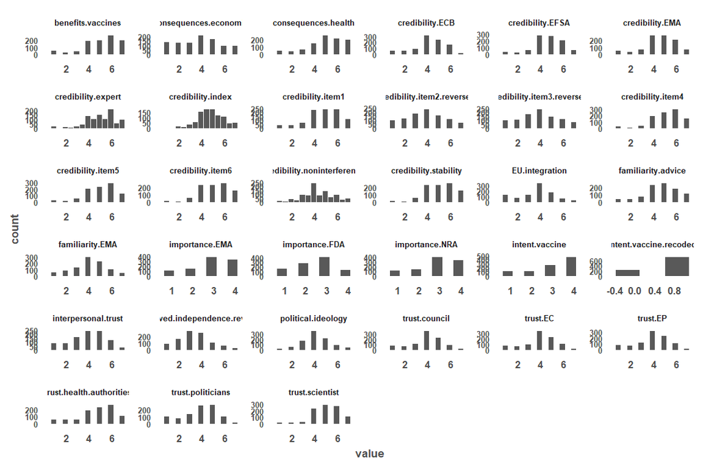

```r
df.def %>% select(benefits.vaccines, intent.vaccine:importance.NRA) %>%
  gather() %>%
  ggplot(aes(value)) +
    facet_wrap(~ key, scales = "free") +
    geom_histogram(boundary = 0.1, binwidth = 0.5) +
  theme(text = element_text(face = "bold",  size = 6), axis.text.y = element_text(size = 5))
```

# 7 Correlation matrix

```r
df.def %>%
  select(trust.EC:trust.politicians, trust.health.authorities, benefits.vaccines, credibility.index, credibility.EMA, familiarity.EMA, familiarity.advice, consequences.economic, consequences.health, age, perceived.independence.reversed, political.ideology, EU.integration, knowledge, interpersonal.trust, treatment, private.providers) %>%
  tab_corr(triangle="lower",
           remove.spaces=T,
           p.numeric = T,
           fade.ns = T,
           digits = 2,
           na.deletion="pairwise",
           title = "Correlation matrix")
```

Correlation matrix

|  | trust.EC | trust.EP | trust.council | trust.scientist | trust.politicians | trust.health.authorities | benefits.vaccines | credibility.index | credibility.EMA | familiarity.EMA | familiarity.advice | consequences.economic | consequences.health | age | perceived.independence.reversed | political.ideology | EU.integration | knowledge | interpersonal.trust | treatment | private.providers |
| --- | --- | --- | --- | --- | --- | --- | --- | --- | --- | --- | --- | --- | --- | --- | --- | --- | --- | --- | --- | --- | --- |
| trust.EC |  |  |  |  |  |  |  |  |  |  |  |  |  |  |  |  |  |  |  |  |  |
| trust.EP | 0.93 (<.001) |  |  |  |  |  |  |  |  |  |  |  |  |  |  |  |  |  |  |  |  |
| trust.council | 0.92 (<.001) | 0.92 (<.001) |  |  |  |  |  |  |  |  |  |  |  |  |  |  |  |  |  |  |  |
| trust.scientist | 0.54 (<.001) | 0.53 (<.001) | 0.55 (<.001) |  |  |  |  |  |  |  |  |  |  |  |  |  |  |  |  |  |  |
| trust.politicians | 0.66 (<.001) | 0.69 (<.001) | 0.67 (<.001) | 0.50 (<.001) |  |  |  |  |  |  |  |  |  |  |  |  |  |  |  |  |  |
| trust.health.authorities | 0.55 (<.001) | 0.53 (<.001) | 0.53 (<.001) | 0.48 (<.001) | 0.58 (<.001) |  |  |  |  |  |  |  |  |  |  |  |  |  |  |  |  |
| benefits.vaccines | 0.46 (<.001) | 0.48 (<.001) | 0.47 (<.001) | 0.57 (<.001) | 0.49 (<.001) | 0.59 (<.001) |  |  |  |  |  |  |  |  |  |  |  |  |  |  |  |
| credibility.index | 0.44 (<.001) | 0.44 (<.001) | 0.45 (<.001) | 0.46 (<.001) | 0.46 (<.001) | 0.61 (<.001) | 0.68 (<.001) |  |  |  |  |  |  |  |  |  |  |  |  |  |  |
| credibility.EMA | 0.65 (<.001) | 0.64 (<.001) | 0.63 (<.001) | 0.57 (<.001) | 0.54 (<.001) | 0.56 (<.001) | 0.62 (<.001) | 0.61 (<.001) |  |  |  |  |  |  |  |  |  |  |  |  |  |
| familiarity.EMA | 0.16 (<.001) | 0.16 (<.001) | 0.15 (<.001) | 0.09 (<.001) | 0.16 (<.001) | 0.19 (<.001) | 0.11 (<.001) | 0.11 (<.001) | 0.12 (<.001) |  |  |  |  |  |  |  |  |  |  |  |  |
| familiarity.advice | 0.16 (<.001) | 0.15 (<.001) | 0.14 (<.001) | 0.19 (<.001) | 0.16 (<.001) | 0.19 (<.001) | 0.22 (<.001) | 0.24 (<.001) | 0.23 (<.001) | 0.58 (<.001) |  |  |  |  |  |  |  |  |  |  |  |
| consequences.economic | -0.00 (.99) | -0.01 (.83) | -0.00 (.98) | -0.05 (.11) | -0.04 (.22) | 0.02 (.58) | -0.07 (.03) | -0.12 (<.001) | -0.07 (.03) | 0.12 (<.001) | -0.02 (.47) |  |  |  |  |  |  |  |  |  |  |
| consequences.health | 0.25 (<.001) | 0.25 (<.001) | 0.24 (<.001) | 0.19 (<.001) | 0.23 (<.001) | 0.42 (<.001) | 0.34 (<.001) | 0.29 (<.001) | 0.28 (<.001) | 0.13 (<.001) | 0.09 (.01) | 0.34 (<.001) |  |  |  |  |  |  |  |  |  |
| age | -0.12 (<.001) | -0.14 (<.001) | -0.14 (<.001) | -0.07 (.02) | -0.11 (<.001) | 0.12 (<.001) | 0.07 (.02) | 0.16 (<.001) | 0.02 (.54) | 0.07 (.02) | 0.08 (.02) | -0.09 (.01) | 0.12 (<.001) |  |  |  |  |  |  |  |  |
| perceived.independence.reversed | 0.13 (<.001) | 0.14 (<.001) | 0.15 (<.001) | 0.09 (<.001) | 0.12 (<.001) | 0.12 (<.001) | 0.18 (<.001) | 0.38 (<.001) | 0.21 (<.001) | -0.12 (<.001) | -0.02 (.43) | -0.21 (<.001) | 0.00 (.89) | 0.07 (.03) |  |  |  |  |  |  |  |
| political.ideology | -0.22 (<.001) | -0.22 (<.001) | -0.22 (<.001) | -0.14 (<.001) | -0.15 (<.001) | -0.18 (<.001) | -0.18 (<.001) | -0.18 (<.001) | -0.15 (<.001) | 0.09 (<.001) | 0.03 (.36) | 0.06 (.06) | -0.08 (.01) | 0.04 (.21) | -0.16 (<.001) |  |  |  |  |  |  |
| EU.integration | 0.59 (<.001) | 0.59 (<.001) | 0.57 (<.001) | 0.29 (<.001) | 0.44 (<.001) | 0.43 (<.001) | 0.33 (<.001) | 0.34 (<.001) | 0.40 (<.001) | 0.14 (<.001) | 0.11 (<.001) | 0.06 (.06) | 0.19 (<.001) | -0.08 (.01) | 0.09 (<.001) | -0.19 (<.001) |  |  |  |  |  |
| knowledge | 0.03 (.41) | 0.02 (.44) | 0.04 (.22) | 0.11 (<.001) | 0.06 (.04) | 0.15 (<.001) | 0.20 (<.001) | 0.21 (<.001) | 0.13 (<.001) | 0.03 (.31) | 0.16 (<.001) | -0.06 (.05) | 0.17 (<.001) | 0.17 (<.001) | 0.06 (.06) | -0.04 (.22) | -0.00 (.96) |  |  |  |  |
| interpersonal.trust | 0.32 (<.001) | 0.33 (<.001) | 0.33 (<.001) | 0.30 (<.001) | 0.35 (<.001) | 0.35 (<.001) | 0.27 (<.001) | 0.32 (<.001) | 0.33 (<.001) | 0.15 (<.001) | 0.18 (<.001) | -0.06 (.04) | 0.05 (.10) | 0.02 (.48) | 0.10 (<.001) | -0.10 (<.001) | 0.35 (<.001) | 0.05 (.09) |  |  |  |
| treatment | -0.07 (.04) | -0.07 (.03) | -0.05 (.12) | -0.03 (.38) | -0.05 (.11) | -0.05 (.15) | -0.01 (.78) | -0.01 (.84) | -0.05 (.11) | -0.05 (.12) | -0.02 (.46) | -0.01 (.78) | -0.01 (.67) | 0.06 (.08) | 0.06 (.06) | 0.03 (.34) | -0.05 (.14) | 0.02 (.57) | 0.01 (.73) |  |  |
| private.providers | -0.00 (.92) | -0.01 (.87) | -0.00 (.92) | -0.03 (.28) | -0.03 (.27) | -0.01 (.72) | -0.05 (.13) | -0.11 (<.001) | -0.05 (.08) | 0.11 (<.001) | -0.05 (.13) | 0.10 (<.001) | 0.04 (.16) | -0.01 (.86) | -0.18 (<.001) | 0.17 (<.001) | 0.00 (.90) | -0.09 (<.001) | -0.06 (.08) | -0.00 (.92) |  |
| Computed correlation used pearson-method with pairwise-deletion. |  |  |  |  |  |  |  |  |  |  |  |  |  |  |  |  |  |  |  |  |  |

# 8 Distributions of items

Item 1: I believe that the opinion was based strictly on scientific considerations.

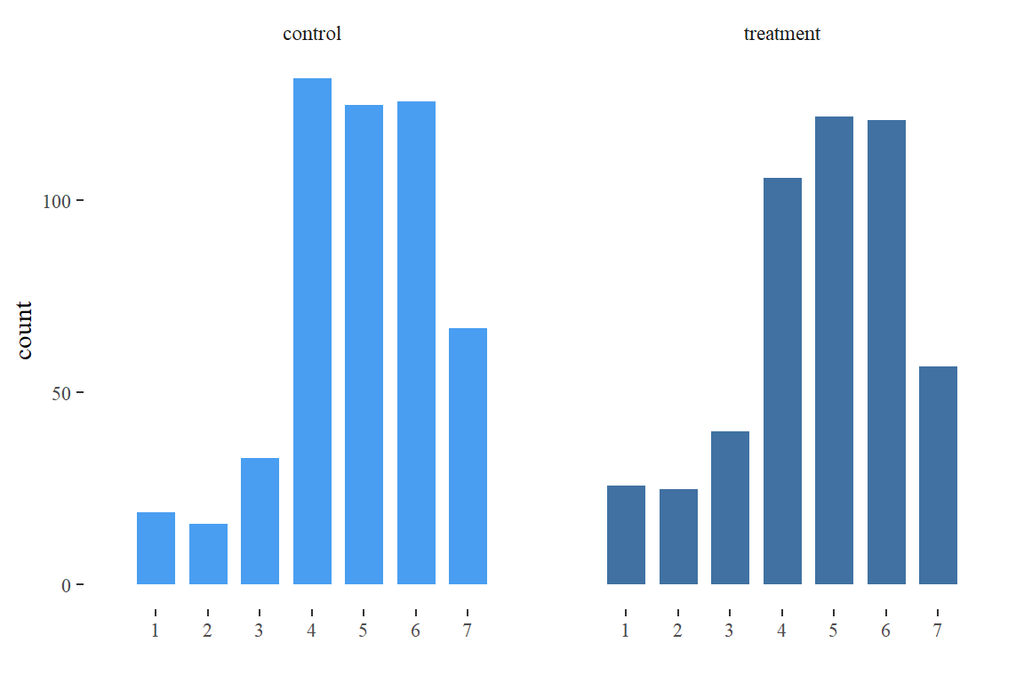

```r
df.def %>%
  drop_na(experimental.group) %>%
  ggplot(aes(x=credibility.item1, fill = experimental.group)) +
  geom_bar(width = 0.75,alpha=0.8)+
  scale_x_continuous(name="",limits = c(0,8),breaks = 1:7)+
  scale_fill_manual(values = c("dodgerblue2","dodgerblue4"))+
  facet_wrap(~experimental.group)+
  theme_tufte()+
  theme(legend.position = "none")
```

Item 2: I believe that the opinion was influenced by political interests. (reversed)

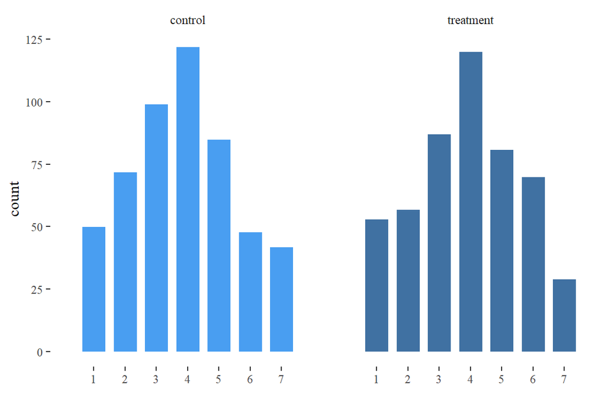

```r
df.def %>%
  drop_na(experimental.group) %>%
  ggplot(aes(x=credibility.item2.reversed, fill = experimental.group)) +
  geom_bar(width = 0.75,alpha=0.8)+
  scale_x_continuous(name="",limits = c(0,8),breaks = 1:7)+
  scale_fill_manual(values = c("dodgerblue2","dodgerblue4"))+
  facet_wrap(~experimental.group)+
  theme_tufte()+
  theme(legend.position = "none")
```

Item 3: I believe that the opinion was affected by the industry interests. (reversed)

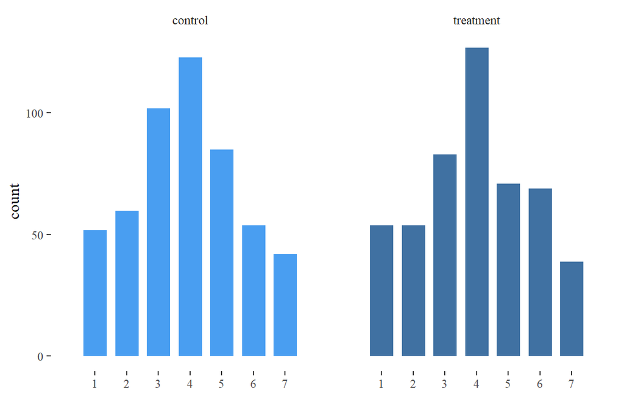

```r
df.def %>%
  drop_na(experimental.group) %>%
  ggplot(aes(x=credibility.item3.reversed, fill = experimental.group)) +
  geom_bar(width = 0.75,alpha=0.8)+
  scale_x_continuous(name="",limits = c(0,8),breaks = 1:7)+
  scale_fill_manual(values = c("dodgerblue2","dodgerblue4"))+
  facet_wrap(~experimental.group)+
  theme_tufte()+
  theme(legend.position = "none")
```

Item 4: I believe that the opinion was formed after evaluating all the relevant data and evidence.

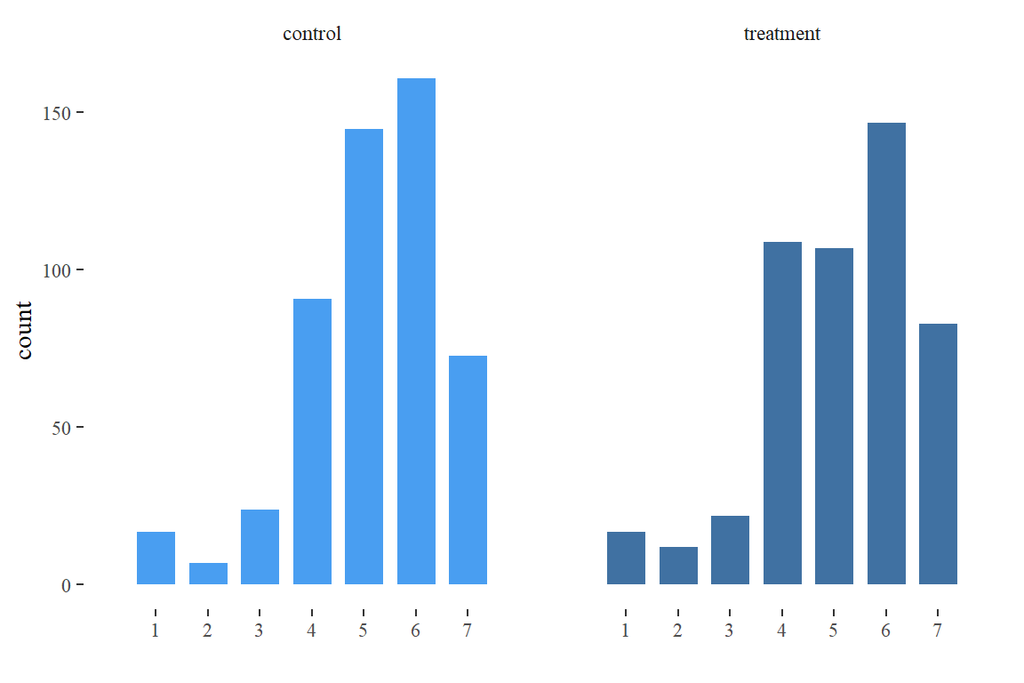

```r
df.def %>%
  drop_na(experimental.group) %>%
  ggplot(aes(x=credibility.item4, fill = experimental.group)) +
  geom_bar(width = 0.75,alpha=0.8)+
  scale_x_continuous(name="",limits = c(0,8),breaks = 1:7)+
  scale_fill_manual(values = c("dodgerblue2","dodgerblue4"))+
  facet_wrap(~experimental.group)+
  theme_tufte()+
  theme(legend.position = "none")
```

Item 5: I believe that the assessment of the evidence was based on adequate methods.

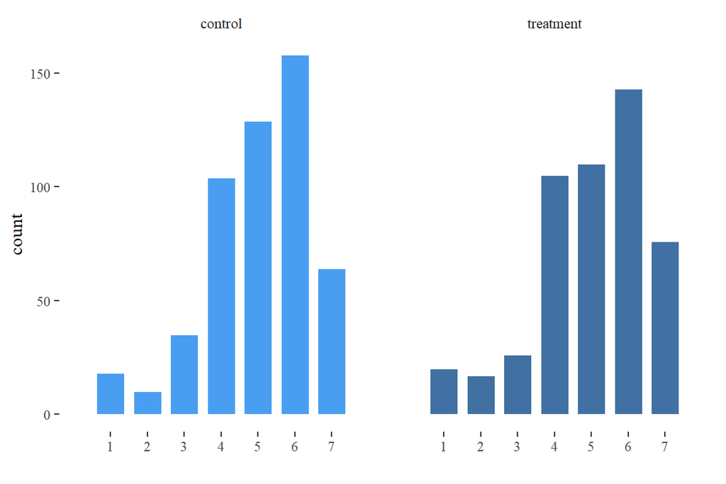

```r
df.def %>%
  drop_na(experimental.group) %>%
  ggplot(aes(x=credibility.item5, fill = experimental.group)) +
  geom_bar(width = 0.75,alpha=0.8)+
  scale_x_continuous(name="",limits = c(0,8),breaks = 1:7)+
  scale_fill_manual(values = c("dodgerblue2","dodgerblue4"))+
  facet_wrap(~experimental.group)+
  theme_tufte()+
  theme(legend.position = "none")
```

Item 6: Assuming that the scientific evidence does not change, I believe that EMA’s opinion about the Pfizer-BioNTech vaccine will not change the next time EMA is asked to re-examine it.

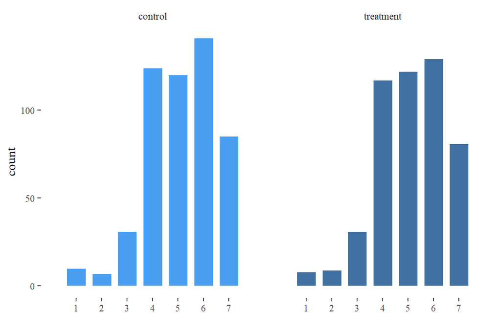

```r
df.def %>%
  drop_na(experimental.group) %>%
  ggplot(aes(x=credibility.item6, fill = experimental.group)) +
  geom_bar(width = 0.75,alpha=0.8)+
  scale_x_continuous(name="",limits = c(0,8),breaks = 1:7)+
  scale_fill_manual(values = c("dodgerblue2","dodgerblue4"))+
  facet_wrap(~experimental.group)+
  theme_tufte()+
  theme(legend.position = "none")
```

**Correlation matrix**

```r
df.def %>%
  select(credibility.item1:credibility.item6) %>%
  tab_corr(triangle="lower",
           remove.spaces=T,
           p.numeric = T,
           fade.ns = T,
           digits = 2,
           na.deletion="pairwise",
           title = "Correlation matrix: items of policy credibility scale")
```

Correlation matrix: items of policy credibility scale

|  | credibility.item1 | credibility.item2.reversed | credibility.item3.reversed | credibility.item4 | credibility.item5 | credibility.item6 |
| --- | --- | --- | --- | --- | --- | --- |
| credibility.item1 |  |  |  |  |  |  |
| credibility.item2.reversed | 0.36 (<.001) |  |  |  |  |  |
| credibility.item3.reversed | 0.33 (<.001) | 0.78 (<.001) |  |  |  |  |
| credibility.item4 | 0.63 (<.001) | 0.45 (<.001) | 0.41 (<.001) |  |  |  |
| credibility.item5 | 0.59 (<.001) | 0.40 (<.001) | 0.42 (<.001) | 0.71 (<.001) |  |  |
| credibility.item6 | 0.41 (<.001) | 0.15 (<.001) | 0.21 (<.001) | 0.44 (<.001) | 0.46 (<.001) |  |
| Computed correlation used pearson-method with pairwise-deletion. |  |  |  |  |  |  |

# 9 Conformitory factor analysis

We conducted our confirmatory factor analysis using `R lavaan` package.

**One-factor model:**

```r
fit.1factor <- cfa(factor.1.cfa,
           std.lv=TRUE,
           missing="fiml",
           data=df.def)

summary(fit.1factor,fit.measures=T,standardize=T)
```

```
## lavaan 0.6-7 ended normally after 17 iterations
##
##   Estimator                                         ML
##   Optimization method                           NLMINB
##   Number of free parameters                         18
##
##   Number of observations                          1015
##   Number of missing patterns                         1
##
## Model Test User Model:
##
##   Test statistic                               709.297
##   Degrees of freedom                                 9
##   P-value (Chi-square)                           0.000
##
## Model Test Baseline Model:
##
##   Test statistic                              2823.217
##   Degrees of freedom                                15
##   P-value                                        0.000
##
## User Model versus Baseline Model:
##
##   Comparative Fit Index (CFI)                    0.751
##   Tucker-Lewis Index (TLI)                       0.584
##
## Loglikelihood and Information Criteria:
##
##   Loglikelihood user model (H0)             -10113.901
##   Loglikelihood unrestricted model (H1)      -9759.253
##
##   Akaike (AIC)                               20263.802
##   Bayesian (BIC)                             20352.410
##   Sample-size adjusted Bayesian (BIC)        20295.240
##
## Root Mean Square Error of Approximation:
##
##   RMSEA                                          0.277
##   90 Percent confidence interval - lower         0.260
##   90 Percent confidence interval - upper         0.294
```

[output cut: 26 more lines]

```
##    .crdblty.tm3.rv    3.915    0.054   72.985    0.000    3.915    2.291
##    .credibilty.tm4    5.133    0.044  116.121    0.000    5.133    3.645
##    .credibilty.tm5    5.017    0.046  109.443    0.000    5.017    3.435
##    .credibilty.tm6    5.115    0.042  120.989    0.000    5.115    3.798
##     policy.crdblty    0.000                               0.000    0.000
##
## Variances:
##                    Estimate  Std.Err  z-value  P(>|z|)   Std.lv  Std.all
##    .credibilty.tm1    1.099    0.058   18.903    0.000    1.099    0.480
##    .crdblty.tm2.rv    1.968    0.095   20.620    0.000    1.968    0.692
##    .crdblty.tm3.rv    2.045    0.099   20.667    0.000    2.045    0.700
##    .credibilty.tm4    0.551    0.040   13.711    0.000    0.551    0.278
##    .credibilty.tm5    0.702    0.045   15.561    0.000    0.702    0.329
##    .credibilty.tm6    1.339    0.063   21.340    0.000    1.339    0.738
##     policy.crdblty    1.000                               1.000    1.000
```

**Three-factors model:**

```r
fit.3factors <- cfa(factor.3.cfa,
           std.lv=TRUE,
           missing="fiml",
           data=df.def)

summary(fit.3factors,fit.measures=T,standardize=T)
```

```
## lavaan 0.6-7 ended normally after 21 iterations
##
##   Estimator                                         ML
##   Optimization method                           NLMINB
##   Number of free parameters                         20
##
##   Number of observations                          1015
##   Number of missing patterns                         1
##
## Model Test User Model:
##
##   Test statistic                               442.321
##   Degrees of freedom                                 7
##   P-value (Chi-square)                           0.000
##
## Model Test Baseline Model:
##
##   Test statistic                              2823.217
##   Degrees of freedom                                15
##   P-value                                        0.000
##
## User Model versus Baseline Model:
##
##   Comparative Fit Index (CFI)                    0.845
##   Tucker-Lewis Index (TLI)                       0.668
##
## Loglikelihood and Information Criteria:
##
##   Loglikelihood user model (H0)              -9980.413
##   Loglikelihood unrestricted model (H1)      -9759.253
##
##   Akaike (AIC)                               20000.826
##   Bayesian (BIC)                             20099.279
##   Sample-size adjusted Bayesian (BIC)        20035.757
##
## Root Mean Square Error of Approximation:
##
##   RMSEA                                          0.248
##   90 Percent confidence interval - lower         0.228
##   90 Percent confidence interval - upper         0.267
```

[output cut: 40 more lines]

```
##     non.interfernc    0.000                               0.000    0.000
##     expert.based      0.000                               0.000    0.000
##     stability         0.000                               0.000    0.000
##
## Variances:
##                    Estimate  Std.Err  z-value  P(>|z|)   Std.lv  Std.all
##    .credibilty.tm1    1.825    0.085   21.489    0.000    1.825    0.797
##    .crdblty.tm2.rv    0.613    0.064    9.554    0.000    0.613    0.216
##    .crdblty.tm3.rv    0.757    0.064   11.802    0.000    0.757    0.259
##    .credibilty.tm4    0.551    0.051   10.742    0.000    0.551    0.278
##    .credibilty.tm5    0.643    0.055   11.717    0.000    0.643    0.301
##    .credibilty.tm6    0.000                               0.000    0.000
##     non.interfernc    1.000                               1.000    1.000
##     expert.based      1.000                               1.000    1.000
##     stability         1.000                               1.000    1.000
```

**Three-factors model alternative:**

In this model, item 1 is part of ‘expertise-based’ instead of ‘non-interference’.

```r
fit.3factors.alt <- cfa(factor.3.cfa.alt,
           std.lv=TRUE,
           missing="fiml",
           data=df.def)

summary(fit.3factors.alt, fit.measures=T, standardize=T)
```

```
## lavaan 0.6-7 ended normally after 21 iterations
##
##   Estimator                                         ML
##   Optimization method                           NLMINB
##   Number of free parameters                         20
##
##   Number of observations                          1015
##   Number of missing patterns                         1
##
## Model Test User Model:
##
##   Test statistic                                27.032
##   Degrees of freedom                                 7
##   P-value (Chi-square)                           0.000
##
## Model Test Baseline Model:
##
##   Test statistic                              2823.217
##   Degrees of freedom                                15
##   P-value                                        0.000
##
## User Model versus Baseline Model:
##
##   Comparative Fit Index (CFI)                    0.993
##   Tucker-Lewis Index (TLI)                       0.985
##
## Loglikelihood and Information Criteria:
##
##   Loglikelihood user model (H0)              -9772.769
##   Loglikelihood unrestricted model (H1)      -9759.253
##
##   Akaike (AIC)                               19585.538
##   Bayesian (BIC)                             19683.990
##   Sample-size adjusted Bayesian (BIC)        19620.469
##
## Root Mean Square Error of Approximation:
##
##   RMSEA                                          0.053
##   90 Percent confidence interval - lower         0.033
##   90 Percent confidence interval - upper         0.075
```

[output cut: 40 more lines]

```
##     non.ntrfrnc.lt    0.000                               0.000    0.000
##     expert.basd.lt    0.000                               0.000    0.000
##     stability.alt     0.000                               0.000    0.000
##
## Variances:
##                    Estimate  Std.Err  z-value  P(>|z|)   Std.lv  Std.all
##    .crdblty.tm2.rv    0.517    0.099    5.248    0.000    0.517    0.182
##    .crdblty.tm3.rv    0.773    0.095    8.151    0.000    0.773    0.265
##    .credibilty.tm1    1.079    0.058   18.712    0.000    1.079    0.471
##    .credibilty.tm4    0.522    0.041   12.740    0.000    0.522    0.263
##    .credibilty.tm5    0.678    0.046   14.823    0.000    0.678    0.318
##    .credibilty.tm6    0.000                               0.000    0.000
##     non.ntrfrnc.lt    1.000                               1.000    1.000
##     expert.basd.lt    1.000                               1.000    1.000
##     stability.alt     1.000                               1.000    1.000
```

## 9.1 A closer look

### 9.1.1 Three factors (original dimensions)

**comparison with one-factor model**

```r
anova(fit.3factors, fit.1factor)
```

```
## Chi-Squared Difference Test
##
##              Df   AIC   BIC  Chisq Chisq diff Df diff Pr(>Chisq)
## fit.3factors  7 20001 20099 442.32
## fit.1factor   9 20264 20352 709.30     266.98       2  < 2.2e-16 ***
## ---
## Signif. codes:  0 '***' 0.001 '**' 0.01 '*' 0.05 '.' 0.1 ' ' 1
```

**Visualization of the model**

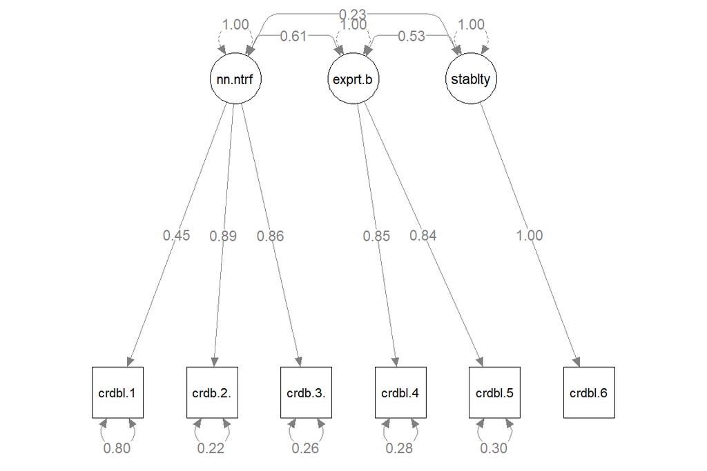

```r
semPaths(fit.3factors, "std", weighted = FALSE, nCharNodes = 7, shapeMan = "rectangle",
         sizeMan = 8,  intercepts = FALSE, edge.label.cex = 1, curvePivot = TRUE)
```

**Factor loading**

```r
parameterEstimates(fit.3factors, standardized=TRUE) %>%
  filter(op == "=~") %>%
  select('Latent Factor'=lhs, Indicator=rhs, B=est, SE=se, Z=z, 'p-value'=pvalue, Beta=std.all) %>%
  mutate(Indicator = str_c("Item ",1:6)) %>%
  kable(digits = 3)%>%
    kable_styling(bootstrap_options = c("condensed"),
                full_width = F,
                position = "left")%>%
  collapse_rows(columns = 1, valign = "top")
```

| Latent Factor | Indicator | B | SE | Z | p-value | Beta |
| --- | --- | --- | --- | --- | --- | --- |
| non.interference | Item 1 | 0.683 | 0.049 | 14.000 | 0 | 0.451 |
|  | Item 2 | 1.494 | 0.046 | 32.734 | 0 | 0.886 |
|  | Item 3 | 1.471 | 0.046 | 31.673 | 0 | 0.861 |
| expert.based | Item 4 | 1.197 | 0.040 | 29.895 | 0 | 0.850 |
|  | Item 5 | 1.221 | 0.042 | 29.293 | 0 | 0.836 |
| stability | Item 6 | 1.347 | 0.030 | 45.056 | 0 | 1.000 |

### 9.1.2 Three factors (alternative)

**comparison with one-factor model**

```r
anova(fit.3factors.alt, fit.1factor)
```

```
## Chi-Squared Difference Test
##
##                  Df   AIC   BIC   Chisq Chisq diff Df diff Pr(>Chisq)
## fit.3factors.alt  7 19586 19684  27.032
## fit.1factor       9 20264 20352 709.297     682.26       2  < 2.2e-16 ***
## ---
## Signif. codes:  0 '***' 0.001 '**' 0.01 '*' 0.05 '.' 0.1 ' ' 1
```

**Visualization of the model**

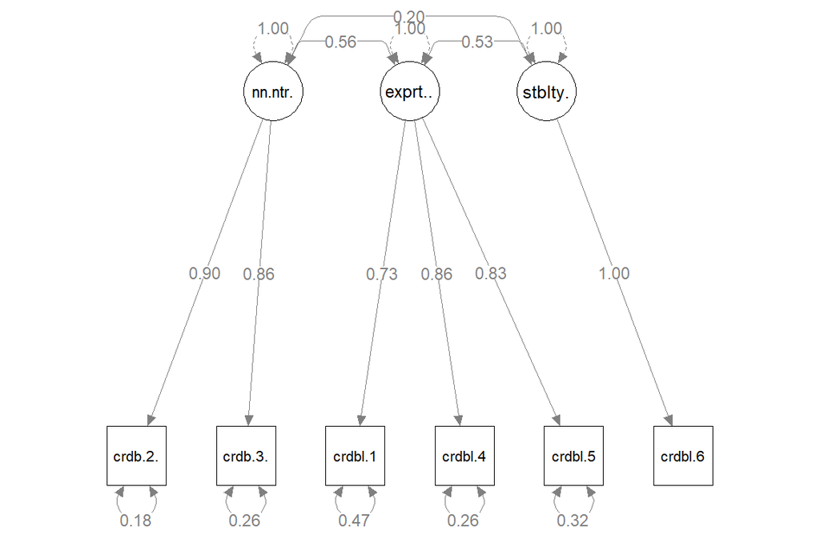

```r
semPaths(fit.3factors.alt, "std", weighted = FALSE, nCharNodes = 7, shapeMan = "rectangle",
         sizeMan = 8,  intercepts = FALSE, edge.label.cex = 1, curvePivot = TRUE)
```

**Factor loading**

```r
parameterEstimates(fit.3factors.alt, standardized=TRUE) %>%
  filter(op == "=~") %>%
  select('Latent Factor'=lhs, Indicator=rhs, B=est, SE=se, Z=z, 'p-value'=pvalue, Beta=std.all) %>%
  mutate(Indicator = str_c("Item ",1:6)) %>%
  kable(digits = 3)%>%
    kable_styling(bootstrap_options = c("condensed"),
                full_width = F,
                position = "left")%>%
  collapse_rows(columns = 1, valign = "top")
```

| Latent Factor | Indicator | B | SE | Z | p-value | Beta |
| --- | --- | --- | --- | --- | --- | --- |
| non.interference.alt | Item 1 | 1.526 | 0.051 | 29.678 | 0 | 0.905 |
|  | Item 2 | 1.466 | 0.052 | 28.048 | 0 | 0.857 |
| expert.based.alt | Item 3 | 1.101 | 0.043 | 25.437 | 0 | 0.727 |
|  | Item 4 | 1.209 | 0.038 | 31.965 | 0 | 0.858 |
|  | Item 5 | 1.206 | 0.040 | 30.273 | 0 | 0.826 |
| stability.alt | Item 6 | 1.347 | 0.030 | 45.056 | 0 | 1.000 |